# Data Analysis Report

# 2 Cluster analysis

## 2.1 Correlation analysis

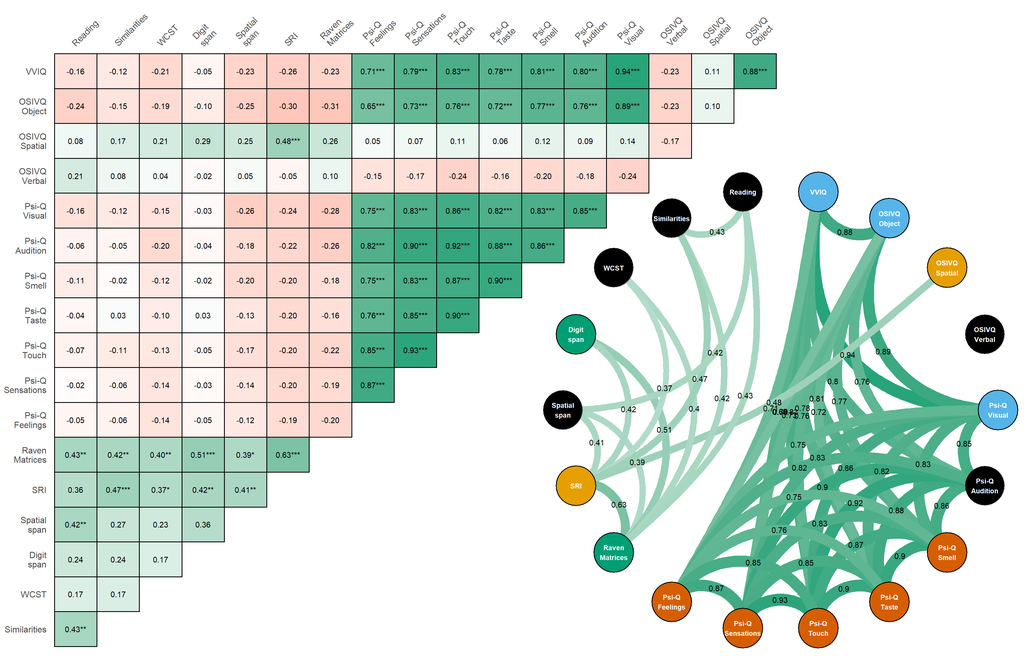

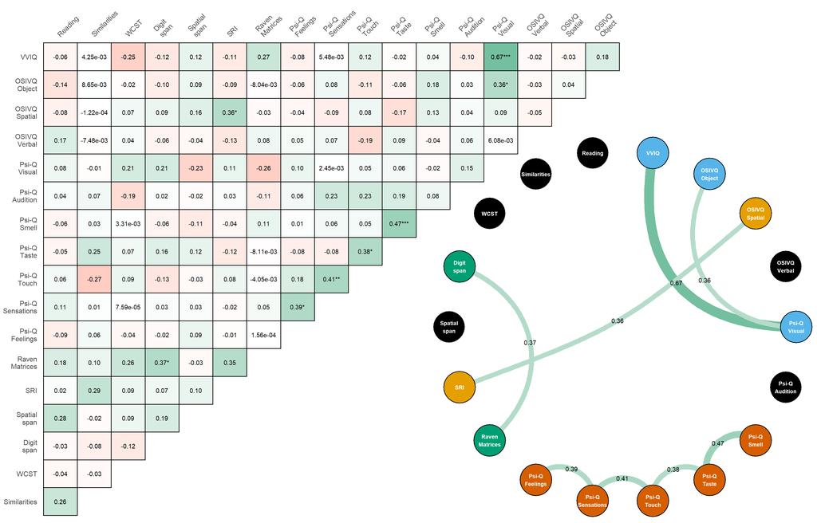

Figure S2.1: Correlation matrix and graph of all the original variables (standardized beforehand)/ The matrix shows the correlation coefficients between all the variables, while the graph shows the significant correlations between them. The colours represent the strength and direction of the correlation: red for negative and green for positive. SRI and Raven Matrices scores are at the heart of a network, but they were only merged together (1) because of their higher correlation, (2) because they have the same format (cognitive test with MCQs) and (3) based on domain knowledge that non-verbal and spatial reasoning are very close constructs.

## 2.2 Number of clusters

The number of clusters was determined using the `NbClust` package (Charrad et al., 2022), which provides 30 indices for determining the number of clusters in a dataset. The most common indices are the silhouette, Dunn, and gap statistics. The `NbClust` package provides the optimal number of clusters based on the majority rule of the indices. The results of this analysis are displayed in Figure S2.2.

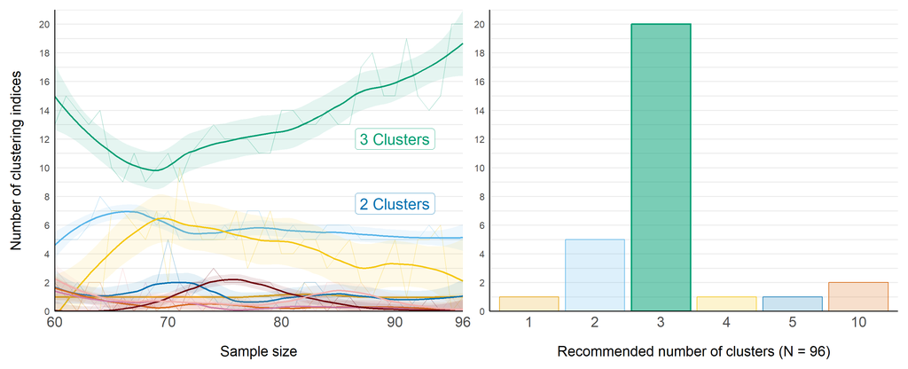

Figure S2.2: Determination of the optimal number of clusters through an unsupervised “agreement” method.

## 2.3 Clustering

| Cluster | Control | Aphantasic |
| --- | --- | --- |
| Cluster A | 34 | 0 |
| Cluster B | 17 | 13 |
| Cluster C | 0 | 32 |

## 2.4 Modelling

| Variable | Cluster A | Cluster B | Cluster C | Cluster | Age | Cluster $\times$ Age |
| --- | --- | --- | --- | --- | --- | --- |
| Visual imagery | 0.73 (0.11) | 0.36 (0.24) | 0.09 (0.07) | 59.35 | -1.56 | -1.65 |
| Auditory imagery | 0.83 (0.17) | 0.58 (0.34) | 0.12 (0.2) | 36.93 | -1.71 | -1.91 |
| Sensory imagery | 0.78 (0.15) | 0.52 (0.31) | 0.1 (0.13) | 44.05 | -1.51 | -2.04 |
| Spatial imagery | 0.56 (0.12) | 0.74 (0.09) | 0.61 (0.11) | 15.15 | -1.70 | -1.97 |
| Verbal strategies | 0.48 (0.13) | 0.45 (0.13) | 0.63 (0.17) | 8.37 | -0.91 | -1.72 |
| Fluid |  |  |  |  |  |  |
| intelligence | 0.61 (0.16) | 0.69 (0.1) | 0.65 (0.13) | -0.56 | -1.85 | -2.72 |
| Verbal reasoning | 0.6 (0.16) | 0.73 (0.08) | 0.65 (0.12) | 3.75 | -1.56 | -2.01 |
| Spatial span | 0.47 (0.22) | 0.66 (0.13) | 0.57 (0.12) | 6.07 | 0.68 | -1.14 |
| WCST | 59.94 (15.89) | 66.63 (14.54) | 65.25 (12.63) | -0.98 | -1.49 | -1.25 |
| Reading |  |  |  |  |  |  |
| comprehension | 16.09 (6.95) | 19.47 (6.07) | 18.47 (4.88) | -0.61 | -1.76 | -2.59 |

| Variable | Cluster 1 | Cluster 2 | Difference | 95% CI | $log(BF_{10})$ |
| --- | --- | --- | --- | --- | --- |
| Visual imagery | Cluster A | Cluster B | 0.36 | [0.29, 0.44] | 17.61 |
| Visual imagery | Cluster A | Cluster C | 0.64 | [0.56, 0.72] | 41.92 |
| Visual imagery | Cluster B | Cluster C | 0.28 | [0.2, 0.36] | 10.19 |
| Auditory imagery | Cluster A | Cluster B | 0.26 | [0.13, 0.38] | 3.31 |
| Auditory imagery | Cluster A | Cluster C | 0.71 | [0.58, 0.83] | 25.26 |
| Auditory imagery | Cluster B | Cluster C | 0.45 | [0.32, 0.57] | 10.41 |
| Sensory imagery | Cluster A | Cluster B | 0.26 | [0.16, 0.37] | 5.59 |
| Sensory imagery | Cluster A | Cluster C | 0.68 | [0.57, 0.78] | 34.32 |
| Sensory imagery | Cluster B | Cluster C | 0.41 | [0.31, 0.52] | 10.99 |
| Spatial imagery | Cluster A | Cluster B | -0.18 | [-0.24, -0.13] | 9.84 |
| Spatial imagery | Cluster A | Cluster C | -0.05 | [-0.1, 0] | -1.73 |
| Spatial imagery | Cluster B | Cluster C | 0.13 | [0.08, 0.19] | 5.11 |
| Verbal strategies | Cluster A | Cluster B | 0.03 | [-0.04, 0.1] | -3.16 |
| Verbal strategies | Cluster A | Cluster C | -0.16 | [-0.23, -0.09] | 4.99 |
| Verbal strategies | Cluster B | Cluster C | -0.19 | [-0.26, -0.12] | 7.04 |
| Fluid |  |  |  |  |  |
| intelligence | Cluster A | Cluster B | -0.08 | [-0.14, -0.01] | -0.81 |
| Fluid |  |  |  |  |  |
| intelligence | Cluster A | Cluster C | -0.03 | [-0.1, 0.03] | -2.78 |
| Fluid |  |  |  |  |  |
| intelligence | Cluster B | Cluster C | 0.04 | [-0.03, 0.11] | -2.97 |
| Verbal reasoning | Cluster A | Cluster B | -0.12 | [-0.19, -0.06] | 2.71 |
| Verbal reasoning | Cluster A | Cluster C | -0.04 | [-0.11, 0.02] | -2.48 |
| Verbal reasoning | Cluster B | Cluster C | 0.08 | [0.02, 0.15] | -0.75 |
| Spatial span | Cluster A | Cluster B | -0.20 | [-0.28, -0.11] | 5.68 |
| Spatial span | Cluster A | Cluster C | -0.12 | [-0.2, -0.03] | 0.41 |
| Spatial span | Cluster B | Cluster C | 0.08 | [0, 0.16] | -1.96 |
| WCST | Cluster A | Cluster B | -7.69 | [-14.91, -0.54] | -1.13 |
| WCST | Cluster A | Cluster C | -5.76 | [-12.78, 1.39] | -2.06 |
| WCST | Cluster B | Cluster C | 1.96 | [-5.28, 9.15] | -3.55 |
| Reading |  |  |  |  |  |
| comprehension | Cluster A | Cluster B | -3.14 | [-6.13, -0.12] | -1.27 |
| Reading |  |  |  |  |  |
| comprehension | Cluster A | Cluster C | -2.24 | [-5.29, 0.75] | -2.26 |
| Reading |  |  |  |  |  |
| comprehension | Cluster B | Cluster C | 0.88 | [-2.2, 4] | -3.52 |

| Variable | Subcluster 1 | Subcluster 2 | Difference | 95% CI | $log(BF_{10})$ |
| --- | --- | --- | --- | --- | --- |
| Visual imagery | A (Control) | (B-Control) | 0.18 | [0.12, 0.24] | 8.98 |
| Visual imagery | A (Control) | (B-Aph.) | 0.61 | [0.54, 0.67] | 45.12 |
| Visual imagery | A (Control) | C (Aph.) | 0.64 | [0.59, 0.69] | 59.76 |
| Visual imagery | (B-Control) | (B-Aph.) | 0.43 | [0.36, 0.5] | 28.69 |
| Visual imagery | (B-Control) | C (Aph.) | 0.46 | [0.4, 0.52] | 33.72 |
| Visual imagery | (B-Aph.) | C (Aph.) | 0.03 | [-0.03, 0.1] | -4.28 |
| Auditory imagery | A (Control) | (B-Control) | 0.14 | [0.01, 0.28] | -1.66 |
| Auditory imagery | A (Control) | (B-Aph.) | 0.44 | [0.29, 0.59] | 6.73 |
| Auditory imagery | A (Control) | C (Aph.) | 0.71 | [0.59, 0.82] | 25.36 |
| Auditory imagery | (B-Control) | (B-Aph.) | 0.30 | [0.13, 0.47] | 1.62 |
| Auditory imagery | (B-Control) | C (Aph.) | 0.56 | [0.43, 0.7] | 14.98 |
| Auditory imagery | (B-Aph.) | C (Aph.) | 0.26 | [0.11, 0.42] | 1.68 |
| Sensory imagery | A (Control) | (B-Control) | 0.16 | [0.05, 0.26] | -0.08 |
| Sensory imagery | A (Control) | (B-Aph.) | 0.44 | [0.32, 0.56] | 14.52 |
| Sensory imagery | A (Control) | C (Aph.) | 0.68 | [0.59, 0.77] | 37.25 |
| Sensory imagery | (B-Control) | (B-Aph.) | 0.29 | [0.16, 0.42] | 3.94 |
| Sensory imagery | (B-Control) | C (Aph.) | 0.52 | [0.41, 0.63] | 19.21 |
| Sensory imagery | (B-Aph.) | C (Aph.) | 0.23 | [0.11, 0.35] | 2.25 |
| Spatial imagery | A (Control) | (B-Control) | -0.21 | [-0.27, -0.15] | 11.85 |
| Spatial imagery | A (Control) | (B-Aph.) | -0.16 | [-0.23, -0.09] | 4.55 |
| Spatial imagery | A (Control) | C (Aph.) | -0.05 | [-0.1, 0] | -1.72 |
| Spatial imagery | (B-Control) | (B-Aph.) | 0.05 | [-0.03, 0.13] | -2.97 |
| Spatial imagery | (B-Control) | C (Aph.) | 0.16 | [0.1, 0.22] | 6.33 |
| Spatial imagery | (B-Aph.) | C (Aph.) | 0.11 | [0.04, 0.18] | 0.92 |
| Verbal strategies | A (Control) | (B-Control) | 0.02 | [-0.07, 0.11] | -3.38 |
| Verbal strategies | A (Control) | (B-Aph.) | 0.05 | [-0.04, 0.15] | -3.02 |
| Verbal strategies | A (Control) | C (Aph.) | -0.16 | [-0.23, -0.09] | 4.89 |
| Verbal strategies | (B-Control) | (B-Aph.) | 0.03 | [-0.08, 0.14] | -3.57 |
| Verbal strategies | (B-Control) | C (Aph.) | -0.18 | [-0.27, -0.09] | 3.72 |
| Verbal strategies | (B-Aph.) | C (Aph.) | -0.21 | [-0.31, -0.11] | 3.76 |
| Fluid |  |  |  |  |  |
| intelligence | A (Control) | (B-Control) | -0.05 | [-0.13, 0.03] | -2.60 |
| Fluid |  |  |  |  |  |
| intelligence | A (Control) | (B-Aph.) | -0.12 | [-0.2, -0.03] | 0.14 |
| Fluid |  |  |  |  |  |
| intelligence | A (Control) | C (Aph.) | -0.03 | [-0.1, 0.03] | -2.78 |
| Fluid |  |  |  |  |  |
| intelligence | (B-Control) | (B-Aph.) | -0.07 | [-0.17, 0.03] | -2.62 |
| Fluid |  |  |  |  |  |
| intelligence | (B-Control) | C (Aph.) | 0.02 | [-0.06, 0.1] | -3.51 |
| Fluid |  |  |  |  |  |
| intelligence | (B-Aph.) | C (Aph.) | 0.08 | [0, 0.17] | -1.76 |
| Verbal reasoning | A (Control) | (B-Control) | -0.11 | [-0.19, -0.03] | 0.53 |
| Verbal reasoning | A (Control) | (B-Aph.) | -0.13 | [-0.22, -0.05] | 1.17 |
| Verbal reasoning | A (Control) | C (Aph.) | -0.04 | [-0.11, 0.02] | -2.44 |
| Verbal reasoning | (B-Control) | (B-Aph.) | -0.02 | [-0.12, 0.07] | -3.53 |
| Verbal reasoning | (B-Control) | C (Aph.) | 0.07 | [-0.01, 0.14] | -2.05 |
| Verbal reasoning | (B-Aph.) | C (Aph.) | 0.09 | [0.01, 0.18] | -1.40 |
| Spatial span | A (Control) | (B-Control) | -0.19 | [-0.29, -0.09] | 2.93 |
| Spatial span | A (Control) | (B-Aph.) | -0.21 | [-0.32, -0.1] | 2.62 |
| Spatial span | A (Control) | C (Aph.) | -0.12 | [-0.2, -0.03] | 0.34 |
| Spatial span | (B-Control) | (B-Aph.) | -0.02 | [-0.14, 0.1] | -3.62 |
| Spatial span | (B-Control) | C (Aph.) | 0.07 | [-0.03, 0.17] | -2.67 |
| Spatial span | (B-Aph.) | C (Aph.) | 0.09 | [-0.01, 0.2] | -2.20 |
| WCST | A (Control) | (B-Control) | -9.78 | [-18.29, -1.37] | -0.73 |
| WCST | A (Control) | (B-Aph.) | -5.22 | [-14.61, 4.14] | -2.85 |
| WCST | A (Control) | C (Aph.) | -5.70 | [-12.89, 1.46] | -2.08 |
| WCST | (B-Control) | (B-Aph.) | 4.57 | [-5.9, 15.29] | -3.25 |
| WCST | (B-Control) | C (Aph.) | 4.09 | [-4.55, 12.66] | -3.19 |
| WCST | (B-Aph.) | C (Aph.) | -0.48 | [-9.81, 9.03] | -3.64 |
| Reading |  |  |  |  |  |
| comprehension | A (Control) | (B-Control) | -2.17 | [-5.89, 1.44] | -2.68 |
| Reading |  |  |  |  |  |
| comprehension | A (Control) | (B-Aph.) | -4.23 | [-8.31, -0.23] | -1.30 |
| Reading |  |  |  |  |  |
| comprehension | A (Control) | C (Aph.) | -2.24 | [-5.3, 0.83] | -2.27 |
| Reading |  |  |  |  |  |
| comprehension | (B-Control) | (B-Aph.) | -2.06 | [-6.6, 2.49] | -3.20 |
| Reading |  |  |  |  |  |
| comprehension | (B-Control) | C (Aph.) | -0.07 | [-3.73, 3.66] | -3.63 |
| Reading |  |  |  |  |  |
| comprehension | (B-Aph.) | C (Aph.) | 2.00 | [-2.12, 6.11] | -3.14 |

## 2.5 Visualizations

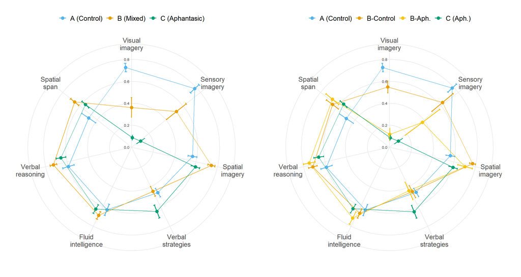

Figure S2.3

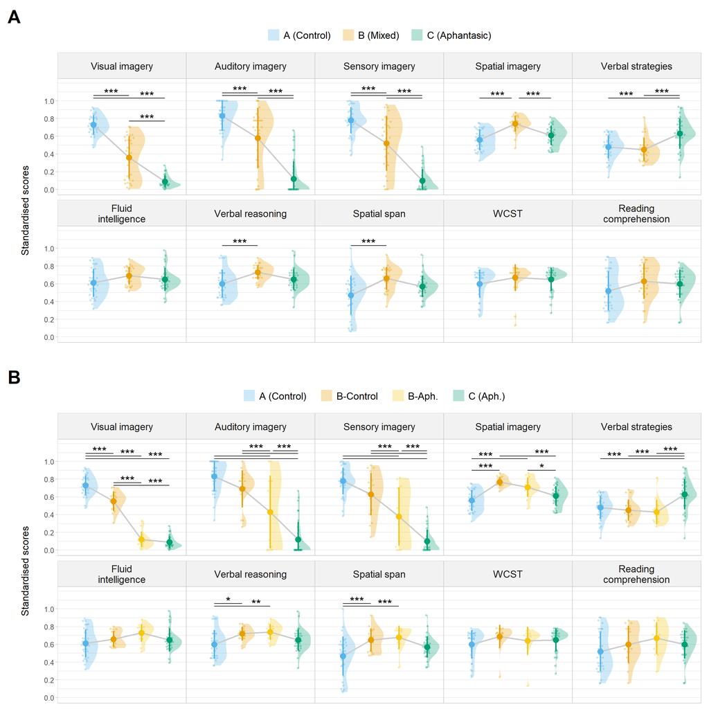

Figure S2.4

# 3 Education, field and occupation

## 3.1 Groups

| Variable | $log(BF_{10})$ |
| --- | --- |
| Education | -4.877559 |
| Field | -5.411238 |
| Occupation | -4.367852 |

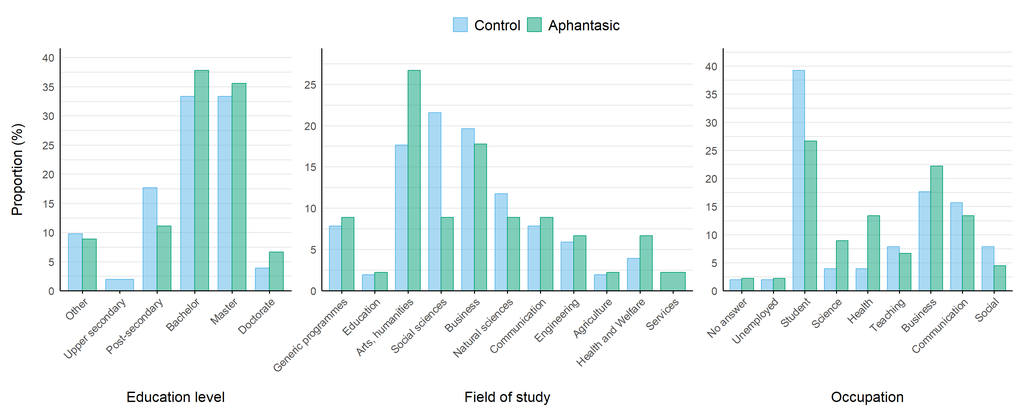

Figure S3.1

## 3.2 Clusters

| Variable | $log(BF_{10})$ |
| --- | --- |
| Education | -7.438704 |
| Field | -7.009316 |
| Occupation | -4.576477 |

| Field | Aph. in B | Aph. in C | Total Aph. |
| --- | --- | --- | --- |
| Generic programmes | 2 | 2 | 4 |
| Arts, humanities | 3 | 9 | 12 |
| Business, Administration, Law | 2 | 6 | 8 |
| Natural sciences, mathematics, statistics | 1 | 3 | 4 |
| Information, communication technologies | 2 | 2 | 4 |
| Engineering, manufacturing, construction | 2 | 1 | 3 |
| Services | 1 | 0 | 1 |
| Education | 0 | 1 | 1 |
| Social sciences, journalism, information | 0 | 4 | 4 |
| Agriculture, forestry, fisheries, veterinary | 0 | 1 | 1 |
| Health and Welfare | 0 | 3 | 3 |

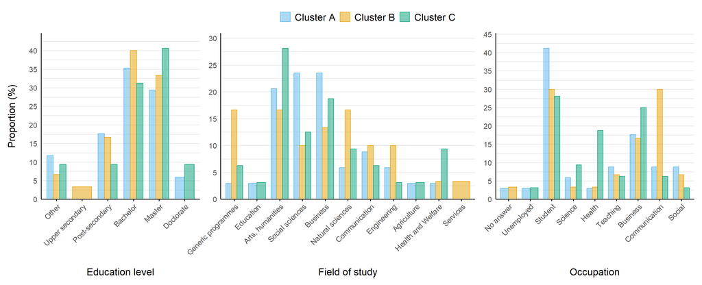

Figure S3.2

## 3.3 Subclusters

| Variable | $log(BF_{10})$ |
| --- | --- |
| Education | -9.839448 |
| Field | -7.952070 |
| Occupation | -7.343397 |

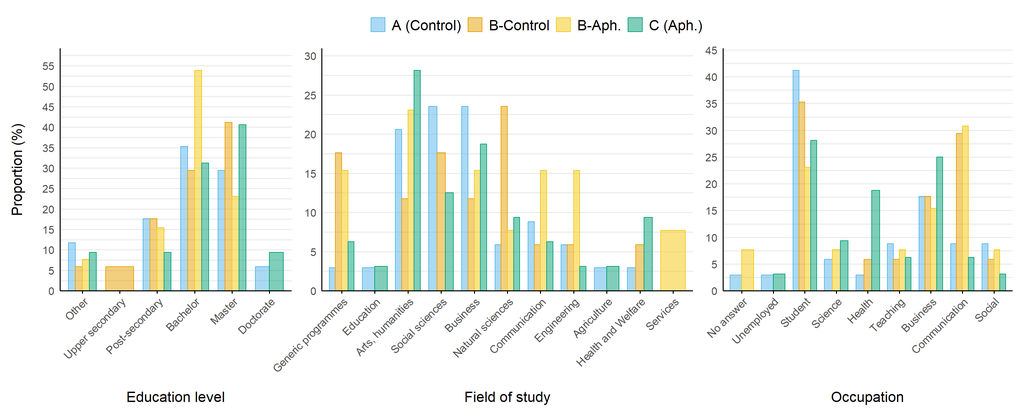

Figure S3.3

## References

Charrad, M., Ghazzali, N., Boiteau, V., & Niknafs, A. (2022). *NbClust: Determining the best number of clusters in a data set*. https://sites.google.com/site/malikacharrad/research/nbclust-package